# Homework 6: Simulating and Fitting Data Distributions

Aura M. Alonso-Rodríguez

February 19, 2020

Full instructions for this homework are available [here](https://gotellilab.github.io/Bio381/Homeworks/Homework06_S2020.html).

For this exercise, I am using seedling height data from the June 2017 seedling census of the Tropical Responses to Altered Climate Experiment (TRACE) plots at Luquillo, Puerto Rico.

```r
library(MASS)
library(ggplot2)

z <- read.table("SeedHt.csv",header=TRUE,sep=",", stringsAsFactors=FALSE)
str(z)
```

```
## 'data.frame':    1369 obs. of  2 variables:
##  $ ID    : int  1 2 3 4 5 6 7 8 9 10 ...
##  $ Height: num  2 5 5 5 5.4 7 7.1 8 8 8.4 ...
```

```r
summary(z)
```

```
##        ID           Height
##  Min.   :   1   Min.   :  2.00
##  1st Qu.: 343   1st Qu.: 11.00
##  Median : 685   Median : 14.00
##  Mean   : 685   Mean   : 17.76
##  3rd Qu.:1027   3rd Qu.: 18.10
##  Max.   :1369   Max.   :148.50
```

#### Plot histogram of data

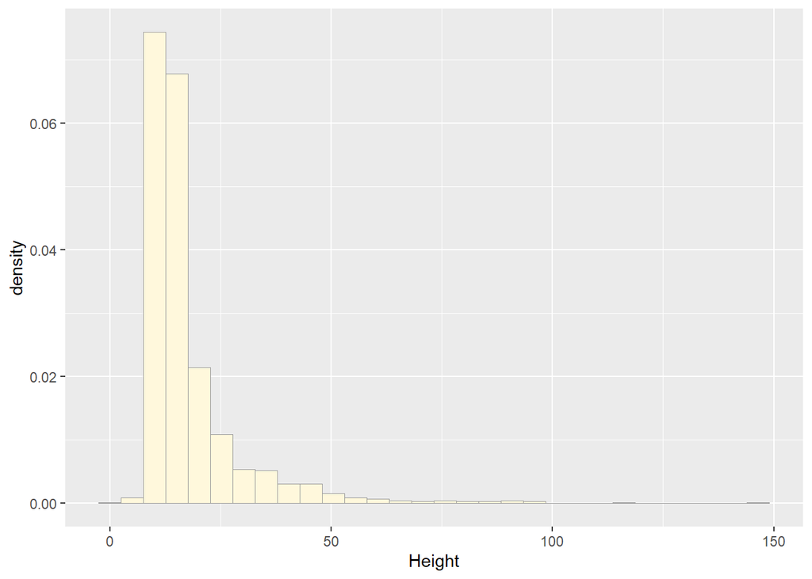

```r
p1 <- ggplot(data=z, aes(x=Height, y=..density..)) +
  geom_histogram(color="grey60",fill="cornsilk",size=0.2)
print(p1)
```

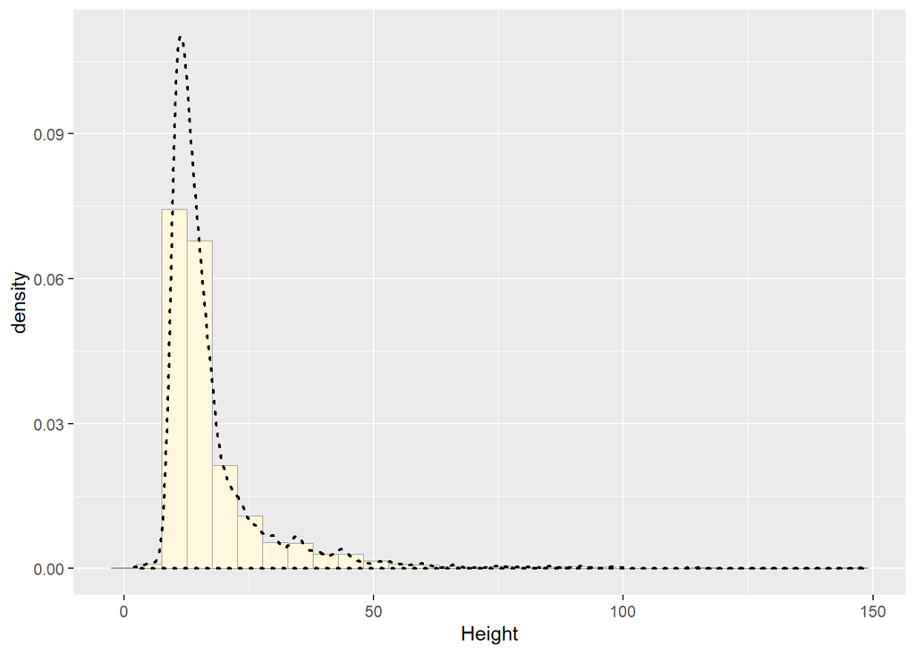

```r
# Add empirical density curve
p1 <-  p1 +  geom_density(linetype="dotted",size=0.75)
print(p1)
```

#### Get maximum likelihood parameters for normal

```r
normPars <- fitdistr(z$Height,"normal")
print(normPars)
```

```
##       mean          sd
##   17.7627465   12.1599397
##  ( 0.3286470) ( 0.2323885)
```

```r
str(normPars)
```

```
## List of 5
##  $ estimate: Named num [1:2] 17.8 12.2
##   ..- attr(*, "names")= chr [1:2] "mean" "sd"
##  $ sd      : Named num [1:2] 0.329 0.232
##   ..- attr(*, "names")= chr [1:2] "mean" "sd"
##  $ vcov    : num [1:2, 1:2] 0.108 0 0 0.054
##   ..- attr(*, "dimnames")=List of 2
##   .. ..$ : chr [1:2] "mean" "sd"
##   .. ..$ : chr [1:2] "mean" "sd"
##  $ n       : int 1369
##  $ loglik  : num -5362
##  - attr(*, "class")= chr "fitdistr"
```

```r
normPars$estimate["mean"] # note structure of getting a named attribute
```

```
##     mean
## 17.76275
```

#### Plot normal probability density

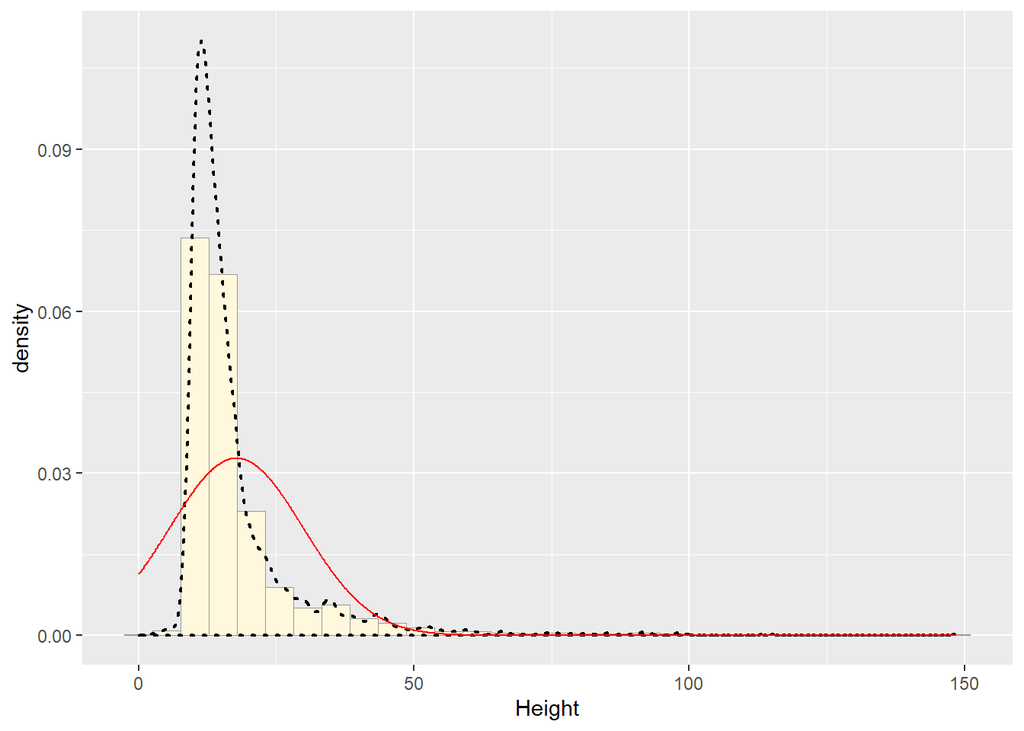

```r
meanML <- normPars$estimate["mean"]
sdML <- normPars$estimate["sd"]

xval <- seq(0,max(z$Height),len=length(z$Height))

stat <- stat_function(aes(x = xval, y = ..y..), fun = dnorm, colour="red", n = length(z$Height), args = list(mean = meanML, sd = sdML))
p1 + stat
```

#### Plot exponential probability density

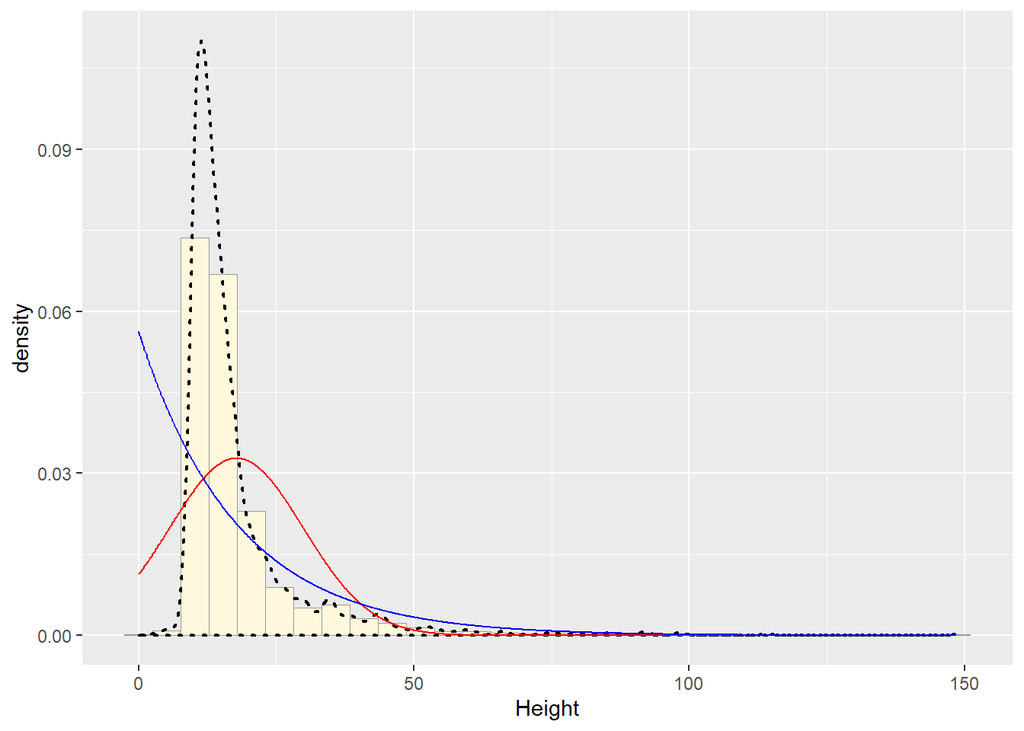

```r
expoPars <- fitdistr(z$Height,"exponential")
rateML <- expoPars$estimate["rate"]

stat2 <- stat_function(aes(x = xval, y = ..y..), fun = dexp, colour="blue", n = length(z$Height), args = list(rate=rateML))
p1 + stat + stat2
```

#### Plot uniform probability density

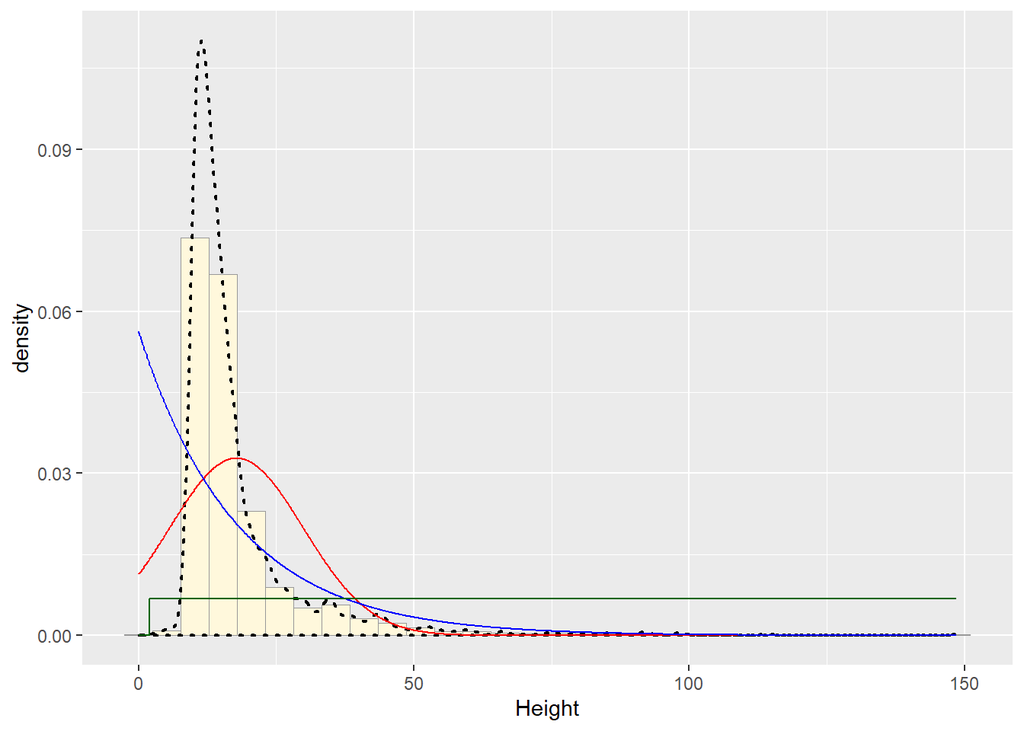

```r
stat3 <- stat_function(aes(x = xval, y = ..y..), fun = dunif, colour="darkgreen", n = length(z$Height), args = list(min=min(z$Height), max=max(z$Height)))
p1 + stat + stat2 + stat3
```

#### Plot gamma probability density

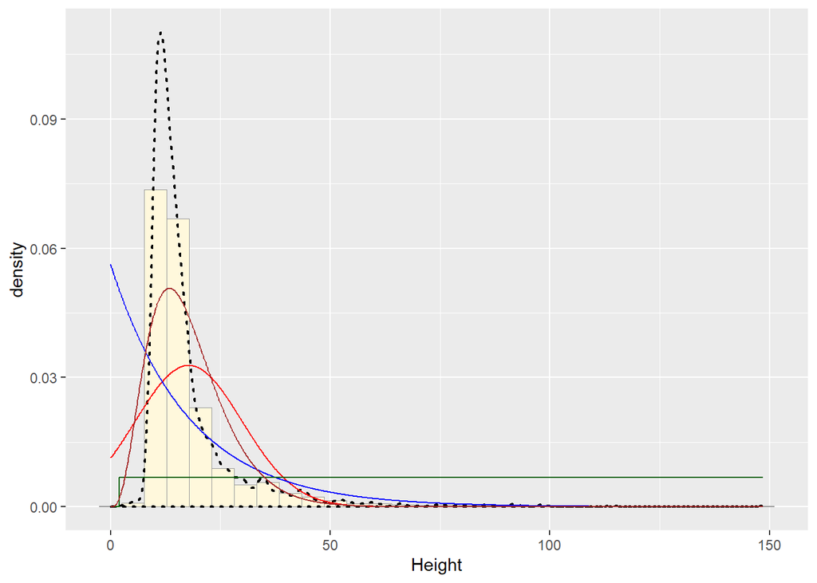

```r
gammaPars <- fitdistr(z$Height,"gamma")
shapeML <- gammaPars$estimate["shape"]
rateML <- gammaPars$estimate["rate"]

stat4 <- stat_function(aes(x = xval, y = ..y..), fun = dgamma, colour="brown", n = length(z$Height), args = list(shape=shapeML, rate=rateML))
p1 + stat + stat2 + stat3 + stat4
```

#### Plot beta probability density

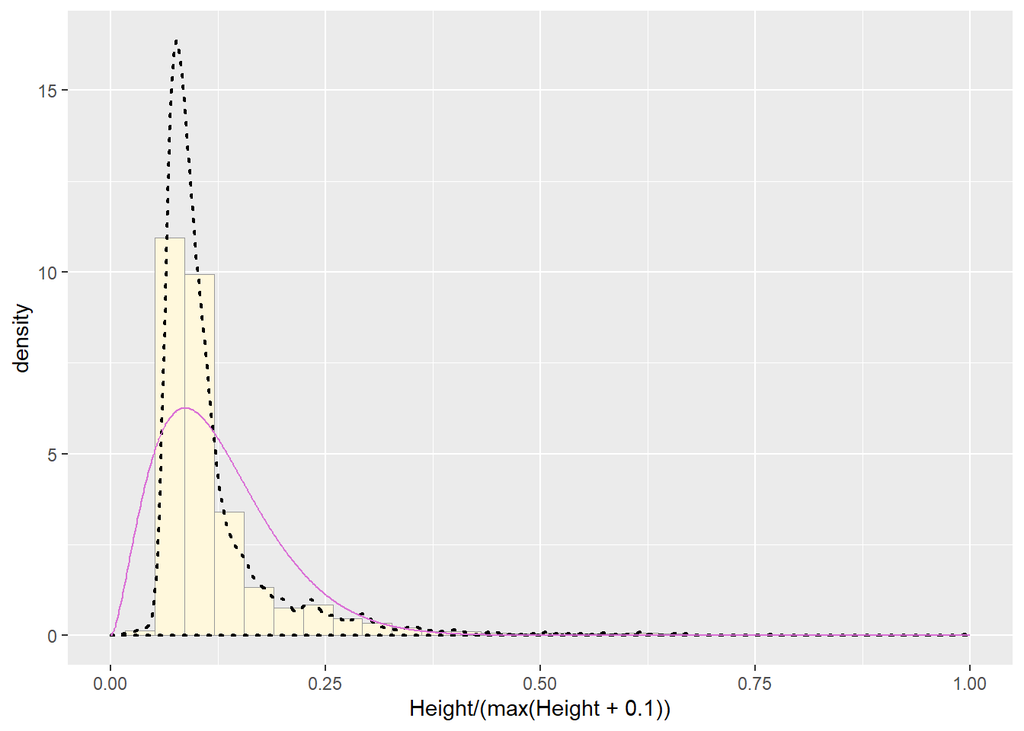

```r
pSpecial <- ggplot(data=z, aes(x=Height/(max(Height + 0.1)), y=..density..)) +
  geom_histogram(color="grey60",fill="cornsilk",size=0.2) +
  xlim(c(0,1)) +
  geom_density(size=0.75,linetype="dotted")

betaPars <- fitdistr(x=z$Height/max(z$Height + 0.1),start=list(shape1=1,shape2=2),"beta")
shape1ML <- betaPars$estimate["shape1"]
shape2ML <- betaPars$estimate["shape2"]

statSpecial <- stat_function(aes(x = xval, y = ..y..), fun = dbeta, colour="orchid", n = length(z$Height), args = list(shape1=shape1ML,shape2=shape2ML))
pSpecial + statSpecial
```

#### Which distribution fits my data the best?

Probably the gamma. However, most of my data is still above the asymptote of the gamma curve. So maybe there is another distribution that fits best?

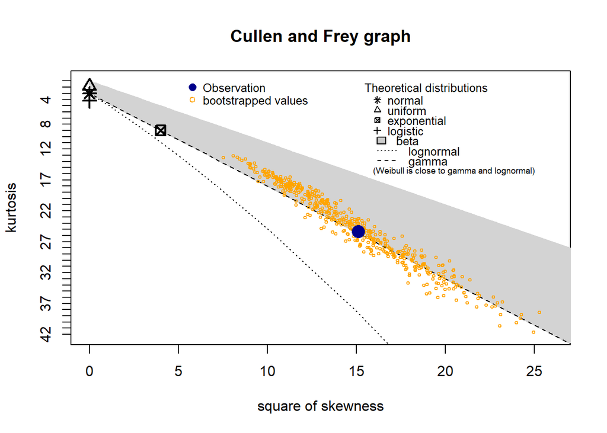

```
## summary statistics
## ------
## min:  2   max:  148.5
## median:  14
## mean:  17.76275
## estimated sd:  12.16438
## estimated skewness:  3.886228
## estimated kurtosis:  25.33269
```

```r
library(fitdistrplus)
descdist(z$Height, discrete=FALSE, boot=500)
```

The Cullen and Frey graph also points to a gamma distribution, so we’ll go with that!

#### Simulation exercise

Using the best-fitting distribution, go back to the code and get the maximum likelihood parameters. Use those to simulate a new data set, with the same length as your original vector, and plot that in a histogram and add the probability density curve. Right below that, generate a fresh histogram plot of the original data, and also include the probability density curve.

```r
#?rgamma
g <- rgamma(n=1369, shapeML, rateML)
g <- data.frame(1:1369,g)
names(g) <- list("ID","myVar")
str(g)
```

```
## 'data.frame':    1369 obs. of  2 variables:
##  $ ID   : int  1 2 3 4 5 6 7 8 9 10 ...
##  $ myVar: num  12.3 26.8 27.5 11.5 18.3 ...
```

```r
summary(g$myVar)
```

```
##    Min. 1st Qu.  Median    Mean 3rd Qu.    Max.
##   1.384  11.566  16.307  17.979  23.161  62.774
```

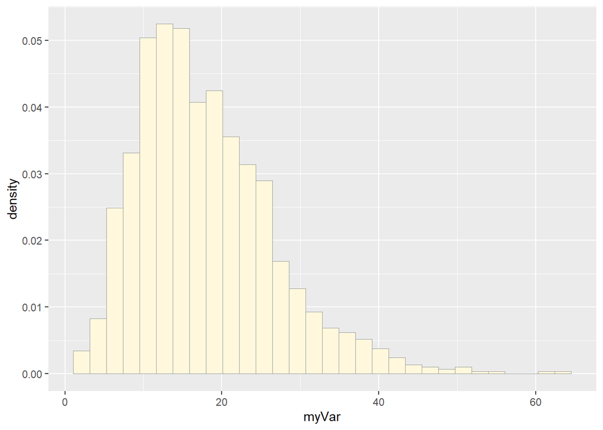

```r
r1 <- ggplot(data=g, aes(x=myVar, y=..density..)) +
  geom_histogram(color="grey60",fill="cornsilk",size=0.2)
print(r1)
```

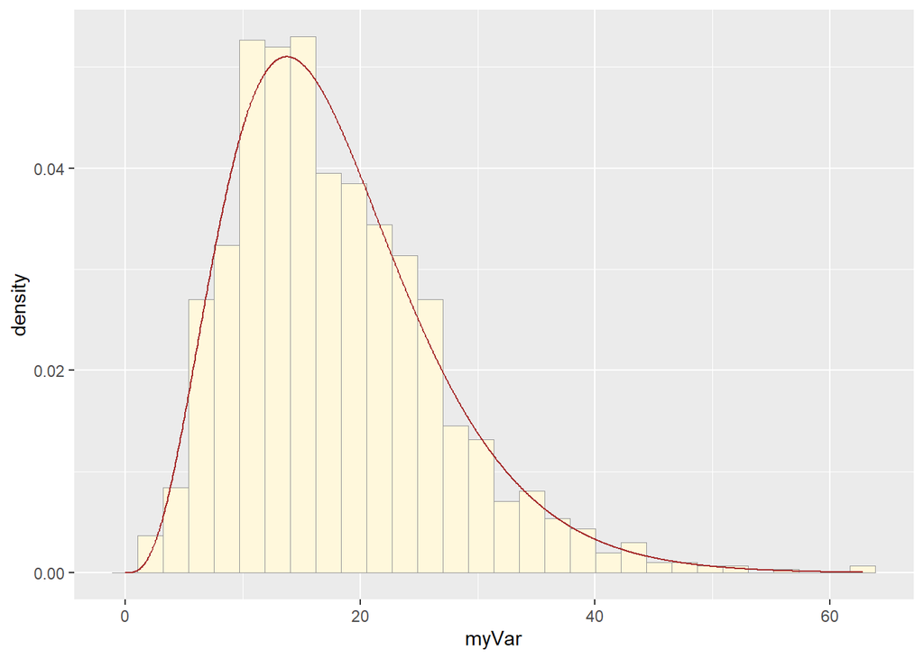

```r
# Add gamma probability density curve
gammaPars1 <- fitdistr(g$myVar,"gamma")
shapeML1 <- gammaPars1$estimate["shape"]
rateML1 <- gammaPars1$estimate["rate"]

xval1 <- seq(0,max(g$myVar),len=length(g$myVar))

stat5 <- stat_function(aes(x = xval1, y = ..y..), fun = dgamma, colour="brown", n = length(g$myVar), args = list(shape=shapeML1, rate=rateML1))
r1 + stat5
```

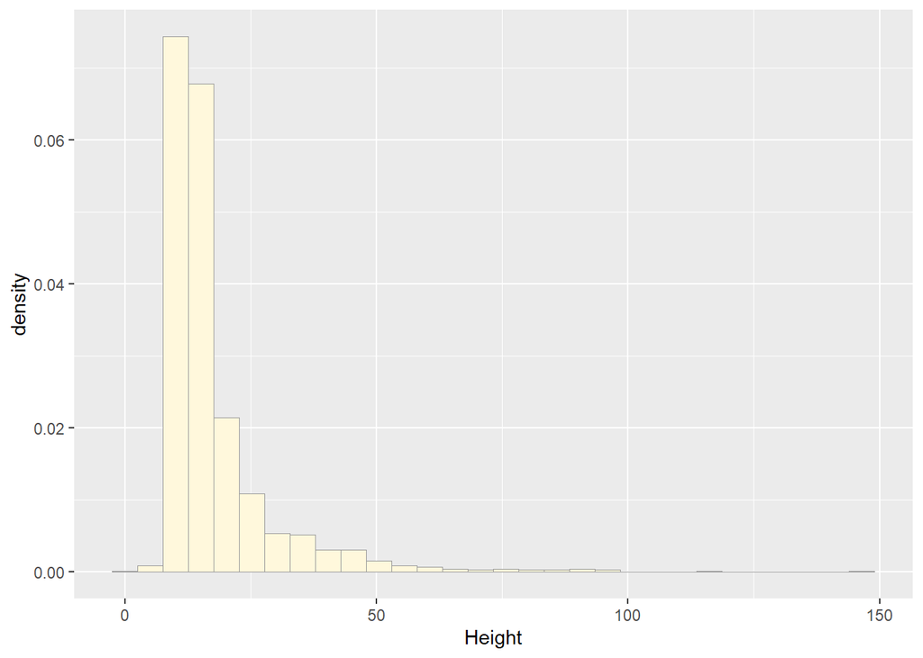

```r
# Plotting histogram of original data
p5 <- ggplot(data=z, aes(x=Height, y=..density..)) +
  geom_histogram(color="grey60",fill="cornsilk",size=0.2)
print(p5)
```

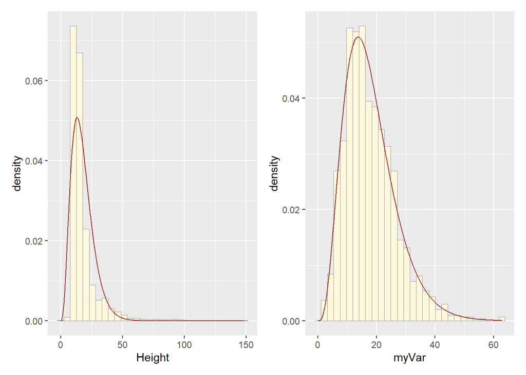

```r
# Plotting histograms of real and simulated data side by side
#install.packages("patchwork")
library(patchwork)
(p5 + stat4) | (r1 + stat5)
```

##### Do you think the model is doing a good job of simulating realistic data that match your original measurements? Why or why not?

The simulation does somewhat match the original data, but it shows a smoother distribution of plant heights. It seems to have removed the very high values (outliers) that were driving the curve towards the right. It also concentrated the majority of the data in between 10 and 30 cm, which seems similar to the real data.